# ISGB-799V: Homework #5 - Hypothesis Testing & Confidence Intervals

Enter Student Name

### Two-Sample Hypothesis Test for Proportions

An online men’s clothing retailer has developed a testing framework for video advertising on YouTube in order to test the effectiveness of the ads on influencing individuals to purchase from their website.

Over the course of 30 days, 600,000 consumers were reached on YouTube. Half of the individuals reached with ads on YouTube were served Public Service Announcement ads, while the other half were served ads for the retailer.

Incrementality testing, also referred to as “Uplift Modeling” or “Incremental Sales Lift”, is a test that measures the impact of a single variable on an individual’s behavior. For digital display or video marketing, it is most commonly used to measure the impact of a branded digital ad (Test Group) against a Public Service Announcement (PSA) ad (Control Group). The lift is measured as the percent difference between the two.

Incremental lift indicates the impact of a particular (digital) advertising tactic on sales – the holy grail of advertising. It is possible to calculate but incremental testing is expensive (budget must still be spent on PSA placebo ads) and subject to many pitfalls unless executed carefully. For the purposes of this assignment we will assume that all individuals were not exposed to any other advertising for the retailer during the 30 day testing period.

The goal of our test is to determine whether the conversion rate of the test group is different than the conversion rate of our control group. Conversion rate in this case is defined as
$$\textrm{Conversion Rate} = \Bigg(\frac{
\textrm{Individuals in Group Who Purchased}}{\textrm{Total Individuals
in Group}}\Bigg)$$

Our hypothesis will test whether the difference in conversion rate or proportion for the test group and control group is statistically significant when $\alpha$ = 0.01.
$$H_0 : p_{test} - p_{control} =
0$$
$$H_a : p_{test} - p_{control}
\neq 0$$

The data we will be using for the following exercises is **test_control.csv**. This data represents a simple random sample of 15,000 individuals served PSA ads and 15,000 individuals served a branded digital video ads. The data also contains an indicator for whether an individual purchased from our retailer after viewing the ad.

1. What variables are available in our data set? List out the column names and describe the data type of each variable.
- Exposed:
  - Two categories which are Test Group (exposed) and Control Group (PSA).
  - Data type: Nominal
- Gender: Male and Female
  - Data type: Nominal
- Age:
  - 5 age groups: 18-25, 25-34, 35-50, 51-65, 65+
  - Data type: Ordinal
- Income:
  - $0 - $25,000, $25,000 - $50,000, $50,001 - $75,000, $75,001 - $100,000, Greater than $100,000
  - Data type: Ordinal
- Purchased: 1 (Yes), 0 (No)
  - Data type: Binary
2. How are our test and control samples defined in our data set?
- Test samples are defined as Test Group (exposed), Control samples are defined as Control Group (PSA)
3. What proportion of individuals from the test group purchased on the retailer’s website after viewing an ad? What proportion of individuals from the control group purchased on the retailer’s website after viewing an ad?

```r
library(dplyr)
data <- read.csv("C:/Users/tuhon/Downloads/test_control.csv")
data_df <- data.frame(data)

# Calculate proportion of purchases in the Test Group
test_group_purchase <- data_df %>%
  filter(exposed == "Test Group (Exposed)") %>%
  summarise(proportion = round(100 * mean(purchased == 1), digits=1))

# Calculate proportion of purchases in the Control Group
control_group_purchase <- data_df %>%
  filter(exposed == "Control Group (PSA)") %>%
  summarise(proportion = round(100 * mean(purchased == 1), digits=1))

test_group_purchase
```

```
##   proportion
## 1        1.2
```

```r
control_group_purchase
```

```
##   proportion
## 1        0.8
```

4. For each of the variables [$gender$, $age$, $income$] create a bar plot to explore the distribution of demographic information in our samples.

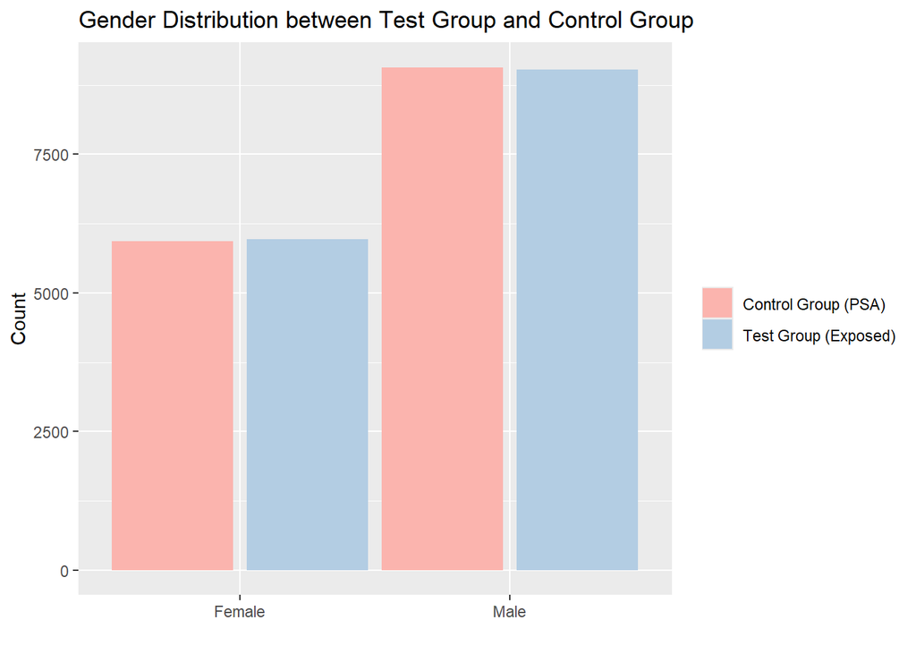

```r
library(ggplot2)

# Gender Distribution Plot
ggplot(data_df, aes(x = gender, fill = exposed)) +
  geom_bar(position = position_dodge(width = 1), stat = "count") +
  labs(title = "Gender Distribution between Test Group and Control Group", x = "", y = "Count", fill = NULL) +
  scale_fill_brewer(palette = "Pastel1")
```

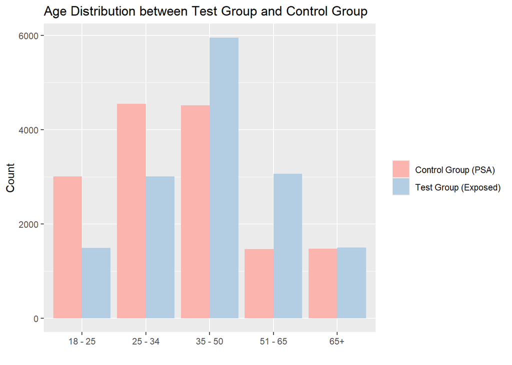

```r
# Age Distribution Plot
ggplot(data_df, aes(x = age, fill = exposed)) +
  geom_bar(position = position_dodge(width = 0.9), stat = "count") +
  labs(title = "Age Distribution between Test Group and Control Group", x = "", y = "Count", fill = NULL) +
  scale_fill_brewer(palette = "Pastel1")
```

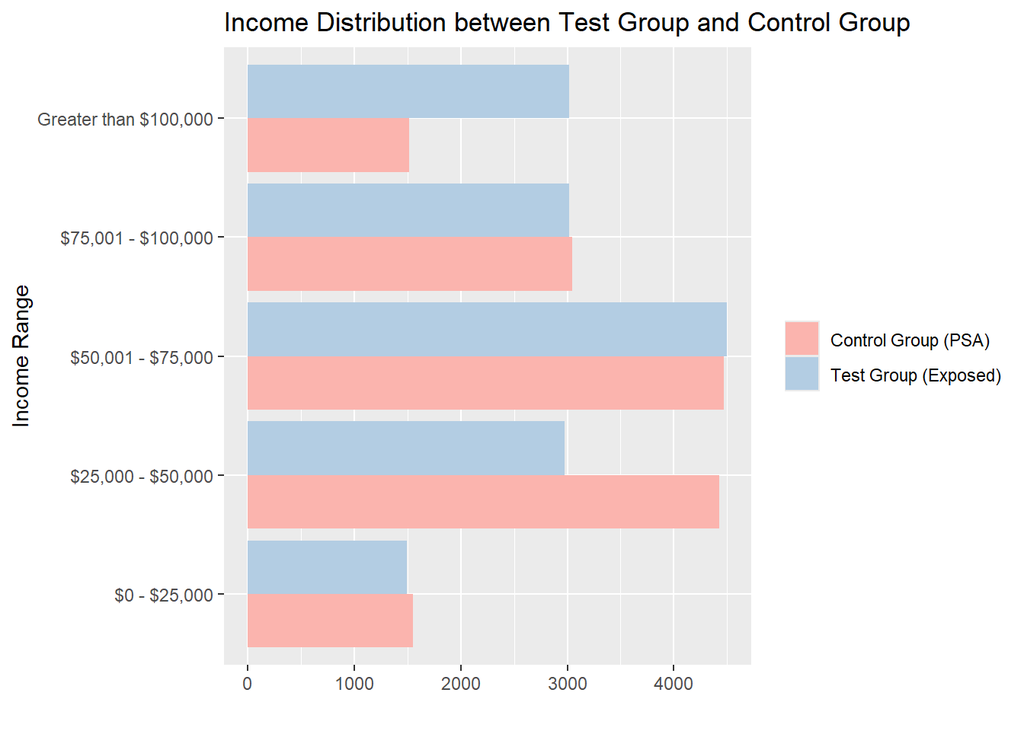

```r
# Income Distribution Plot
ggplot(data_df, aes(x = income, fill = exposed)) +
  geom_bar(stat = "count", position = position_dodge()) +
  labs(title = "Income Distribution between Test Group and Control Group", x = "Income Range", y = "", fill = NULL) +
  scale_fill_brewer(palette = "Pastel1") +
  coord_flip()
```

```r
# Calculate the percentage of each age category within each group
age_data <- data_df %>%
  group_by(exposed, age) %>%
  summarise(count = n()) %>%
  mutate(total = sum(count),
         percentage = (count / total) * 100)
age_data
```

```
## # A tibble: 10 × 5
## # Groups:   exposed [2]
##    exposed              age     count total percentage
##    <chr>                <chr>   <int> <int>      <dbl>
##  1 Control Group (PSA)  18 - 25  3007 15000      20.0
##  2 Control Group (PSA)  25 - 34  4543 15000      30.3
##  3 Control Group (PSA)  35 - 50  4515 15000      30.1
##  4 Control Group (PSA)  51 - 65  1461 15000       9.74
##  5 Control Group (PSA)  65+      1474 15000       9.83
##  6 Test Group (Exposed) 18 - 25  1491 15000       9.94
##  7 Test Group (Exposed) 25 - 34  3001 15000      20.0
##  8 Test Group (Exposed) 35 - 50  5951 15000      39.7
##  9 Test Group (Exposed) 51 - 65  3062 15000      20.4
## 10 Test Group (Exposed) 65+      1495 15000       9.97
```

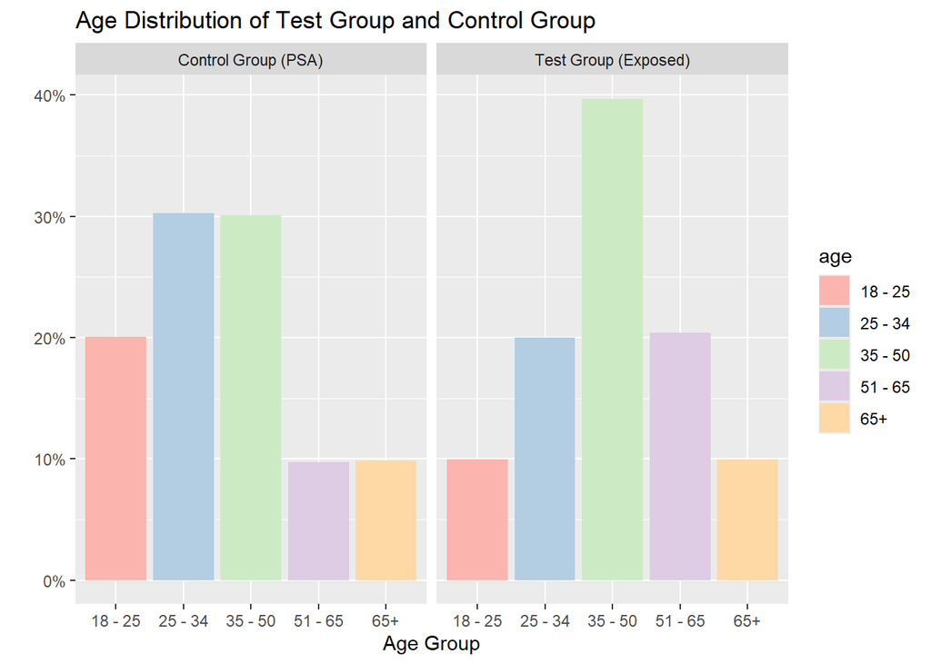

```r
# Create the bar plots
ggplot(age_data, aes(x = age, y = percentage, fill = age)) +
  geom_bar(stat = "identity", position = "dodge") +
  facet_grid(~exposed) +
  labs(title = "Age Distribution of Test Group and Control Group",
       x = "Age Group",
       y = "") +
  scale_y_continuous(labels = scales::percent_format(scale = 1)) +
  scale_fill_brewer(palette = "Pastel1")
```

6. Create a figure with two bar plots (one for the test group and one for the control group) for $gender$. Describe the difference in the distribution between the test and control groups. Add the percentage of each category to your plots. Why might this variable be important to our analysis? Answers:
- Distribution of female and male is nearly equivalent between test group and control group. Male distribution of control group is slightly higher than test group (60.48% vs 60.19%). Female distribution of test group is slightly higher than control group (39.8% vs 39.52%).
- Gender is a demographic variable that can tell whether females or males are more likely to make a purchase after viewing ads or male. Given that female and male have differences preferences and varying likelihoods of being influenced by ads, obtain demographic data of customer is critical for improving conversion rates. In both test group and control group, female distribution is smaller than male distribution. This discrepancy raises questions about the effectiveness of the ads on female, and highlights the need to improve ads campaign to increase female purchasers.

```r
# Calculate the percentage of each gender category within each group
gender_data <- data_df %>%
  group_by(exposed, gender) %>%
  summarise(count = n()) %>%
  mutate(total = sum(count),
         percentage = (count / total) * 100)
gender_data
```

```
## # A tibble: 4 × 5
## # Groups:   exposed [2]
##   exposed              gender count total percentage
##   <chr>                <chr>  <int> <int>      <dbl>
## 1 Control Group (PSA)  Female  5928 15000       39.5
## 2 Control Group (PSA)  Male    9072 15000       60.5
## 3 Test Group (Exposed) Female  5971 15000       39.8
## 4 Test Group (Exposed) Male    9029 15000       60.2
```

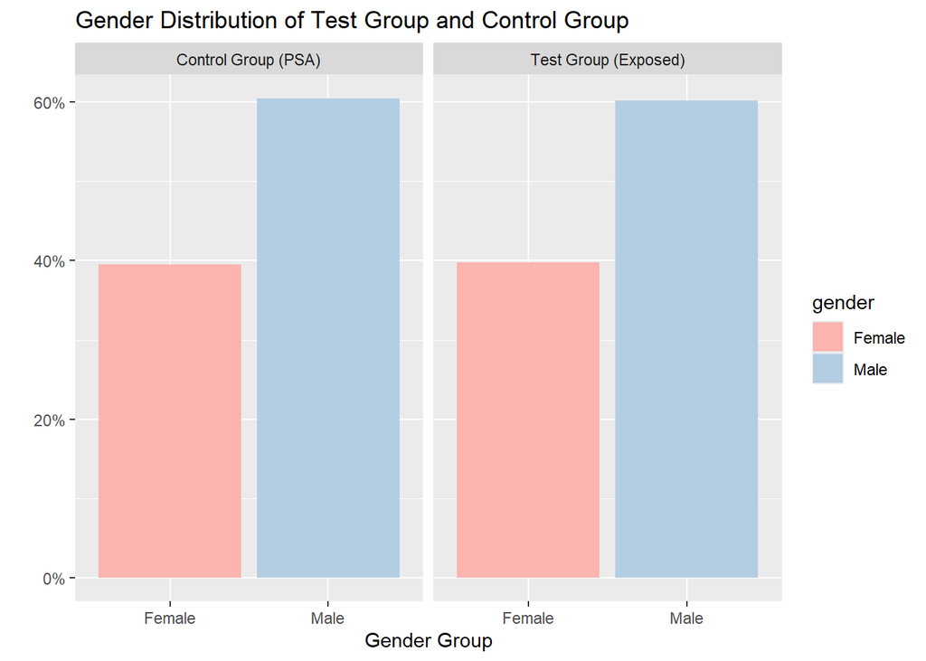

```r
# Create the bar plots
ggplot(gender_data, aes(x = gender, y = percentage, fill = gender)) +
  geom_bar(stat = "identity", position = "dodge") +
  facet_grid(~exposed) +
  labs(title = "Gender Distribution of Test Group and Control Group",
       x = "Gender Group",
       y = "") +
  scale_y_continuous(labels = scales::percent_format(scale = 1)) +
  scale_fill_brewer(palette = "Pastel1")
```

7. Create a figure with two bar plots (one for the test group and one for the control group) for $income$. Describe the difference in the distribution between the test and control groups. Compare the percentage of each category between our test and control groups.
- Comparison of each age bracket:
  - $0-$25000: equivalent between test group and control group (10% vs 10%)
  - $25000-$50000: covers 30% of distribution in control group, higher than in test group with 20%
  - $50001-$75000: equivalent between test group and control group (30% vs 30%)
  - $75001-$100000: equivalent between test group and control group (20% vs 20%)
  - Greater than $100000: accounts for 20% in test group, higher than in control group with 10%.

```r
# Calculate the percentage of each income range within each group
income_data <- data_df %>%
  group_by(exposed, income) %>%
  summarise(count = n()) %>%
  mutate(total = sum(count),
         percentage = (count / total) * 100)
income_data
```

```
## # A tibble: 10 × 5
## # Groups:   exposed [2]
##    exposed              income                count total percentage
##    <chr>                <chr>                 <int> <int>      <dbl>
##  1 Control Group (PSA)  $0 - $25,000           1549 15000      10.3
##  2 Control Group (PSA)  $25,000 - $50,000      4425 15000      29.5
##  3 Control Group (PSA)  $50,001 - $75,000      4466 15000      29.8
##  4 Control Group (PSA)  $75,001 - $100,000     3047 15000      20.3
##  5 Control Group (PSA)  Greater than $100,000  1513 15000      10.1
##  6 Test Group (Exposed) $0 - $25,000           1494 15000       9.96
##  7 Test Group (Exposed) $25,000 - $50,000      2975 15000      19.8
##  8 Test Group (Exposed) $50,001 - $75,000      4500 15000      30
##  9 Test Group (Exposed) $75,001 - $100,000     3015 15000      20.1
## 10 Test Group (Exposed) Greater than $100,000  3016 15000      20.1
```

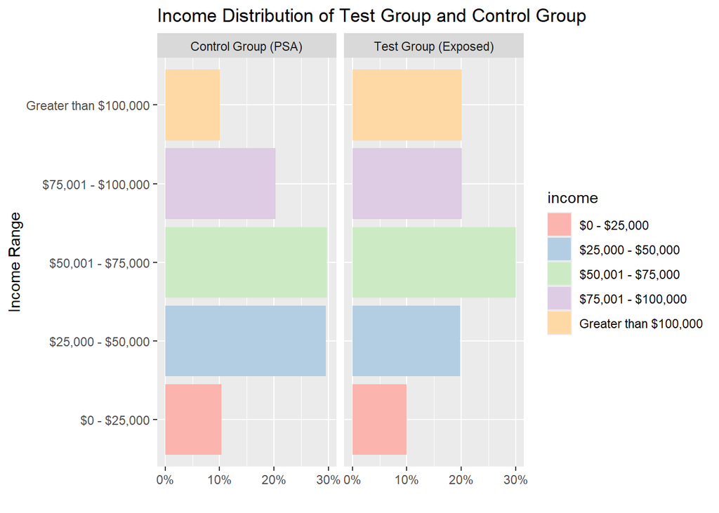

```r
# Create the bar plots
ggplot(income_data, aes(x = income, y = percentage, fill = income)) +
  geom_bar(stat = "identity", position = "dodge") +
  facet_grid(~exposed) +
  labs(title = "Income Distribution of Test Group and Control Group",
       x = "Income Range",
       y = "") +
  scale_y_continuous(labels = scales::percent_format(scale = 1)) +
  scale_fill_brewer(palette = "Pastel1") +
  coord_flip()
```

8. How might the differences in the distributions of the categorical variables analyzed in #5 - #7 impact our analysis? Is it possible that our two samples may represent different types of shoppers?
- The differences in age, income and gender distribution will impact the analysis of customer segmentation in the study. These three variables provide demographic data that describe the characteristics and demographic information of customer who make purchases after viewing ads. Segment customer based on demographic data can help gaining a deeper understanding of each customer group, their preferences, and the effectiveness of ads on each group, which customer group to invest in, and how to improve ad campaigns for better conversion rates.
- Given the distribution of age, income and gender in test group and control group, it is possible that these two samples represent different types of shoppers. As explained above, segment customer based on demographic data provide insights into preferences and needs of different customer group. That means it’s possible that these two samples may represent different types of shoppers.

#### Hypothesis Test

9. What is the difference in the conversion rate for the test and control groups?

```r
conversion <- data_df %>%
  group_by(exposed, purchased) %>%
  summarise(count = n())
conversion
```

```
## # A tibble: 4 × 3
## # Groups:   exposed [2]
##   exposed              purchased count
##   <chr>                    <int> <int>
## 1 Control Group (PSA)          0 14879
## 2 Control Group (PSA)          1   121
## 3 Test Group (Exposed)         0 14819
## 4 Test Group (Exposed)         1   181
```

```r
# Calculate total counts of purchased for each group
totals <- conversion %>%
  group_by(exposed) %>%
  summarise(total = sum(count))

totals
```

```
## # A tibble: 2 × 2
##   exposed              total
##   <chr>                <int>
## 1 Control Group (PSA)  15000
## 2 Test Group (Exposed) 15000
```

```r
# Calculate conversion rate
conversion_rate <- conversion %>%
  left_join(totals, by = "exposed") %>%
  mutate(percentage = (count / total) * 100)

conversion_rate
```

```
## # A tibble: 4 × 5
## # Groups:   exposed [2]
##   exposed              purchased count total percentage
##   <chr>                    <int> <int> <int>      <dbl>
## 1 Control Group (PSA)          0 14879 15000     99.2
## 2 Control Group (PSA)          1   121 15000      0.807
## 3 Test Group (Exposed)         0 14819 15000     98.8
## 4 Test Group (Exposed)         1   181 15000      1.21
```

The confidence interval for the difference between two proportions (when n > 30) is defined as
$$p_{test} -
p_{control} \pm z_{\alpha/2}\sqrt{\frac{p_{test} \times
(1-p_{test})}{n_{test}}+ \frac{p_{control} \times
(1-p_{control})}{n_{control}} }$$

10. Using the equation above, write a function to calculate the confidence interval for the difference between two proportions. Your function should include three arguments: p1, p2, n1, n2 and Z. Your function should return the confidence interval for the difference in two proportions at a given confidence level (in our example, Z = 2.575 when $\alpha$ = 0.01) Round your results to the first five decimal places.

```r
calculate_confidence_interval <- function(p1, p2, n1, n2, Z) {
  standard_error <- sqrt((p1 * (1 - p1) / n1) + (p2 * (1 - p2) / n2))   # Calculate the standard error of the difference between two proportions
  margin_of_error <- Z * standard_error   # Calculate the margin of error
  difference <- p1 - p2   # Calculate the difference in proportions

  # Calculate the confidence interval
  lower_bound <- round(difference - margin_of_error, 5)
  upper_bound <- round(difference + margin_of_error, 5)

  return(c(lower = lower_bound, upper = upper_bound))
}

#Let's test our function
p1 <- 0.01206667   # Test group proportion (1.206667%)
p2 <- 0.00806667   # Control group proportion (0.806667%)
n1 <- 15000        # Test group size
n2 <- 15000        # Control group size
Z <- 2.575         # Z-score for 99% confidence level

confidence_interval <- calculate_confidence_interval(p1, p2, n1, n2, Z)
confidence_interval
```

```
##   lower   upper
## 0.00103 0.00697
```

11. Calculate the confidence interval for the difference between the conversion rates for our test and control groups when $\alpha$ = 0.01 (Z = 2.575) using your function. Does this confidence interval include zero? What are the implications for the difference between two means when the confidence interval does not include zero?
- Answer: The confidence interval output doesn’t contain zero, which suggests that there is a statistically significant difference between the conversion rates of the test and control groups. This means that the test group had a statistically significant effect on the outcome compared to the control.

```r
# Conversion rates and sample sizes
p_control <- 0.00806667
p_test <- 0.01206667
n_control <- 15000
n_test <- 15000
Z <- 2.575

# Calculate the confidence interval
confidence_interval <- calculate_confidence_interval(p_test, p_control, n_test, n_control, Z)
confidence_interval
```

```
##   lower   upper
## 0.00103 0.00697
```

12. Similar to the `t.test()` function in R, the `prop.test()` function can be used for testing the null hypothesis that the proportions (probabilities of success) in several groups are the same, or that they equal certain given values. A chi-square test for equality of two proportions is exactly the same test as a z-test (chi-squared distribution with one degree of freedom is just that of a normal deviate, squared). What are the arguments for the function `prop.test()`?

```r
successes <- c(50, 30) # Number of successes in each group
trials <- c(200, 200) # Number of trials (or observations) in each group

result <- prop.test(successes, trials)
result
```

```
##
##  2-sample test for equality of proportions with continuity correction
##
## data:  successes out of trials
## X-squared = 5.6406, df = 1, p-value = 0.01755
## alternative hypothesis: two.sided
## 95 percent confidence interval:
##  0.01721634 0.18278366
## sample estimates:
## prop 1 prop 2
##   0.25   0.15
```

13. Noting that the arguments `x` and `n` require vectors of values, use the `prop.test()` function to test our hypothesis that there is a statistically significant difference between the conversion rates of our test and control groups.

```r
successes <- c(181, 121)  # Test Group, Control Group
trials <- c(15000, 15000)  # Size of both groups

test_result <- prop.test(successes, trials)

test_result
```

```
##
##  2-sample test for equality of proportions with continuity correction
##
## data:  successes out of trials
## X-squared = 11.644, df = 1, p-value = 0.0006442
## alternative hypothesis: two.sided
## 95 percent confidence interval:
##  0.001674542 0.006325458
## sample estimates:
##      prop 1      prop 2
## 0.012066667 0.008066667
```

14. Interpet each output of `prop.test`. Explain your p-value in the context of our hypothesis. Is the difference in the conversion rates for the test and control groups statistically significant?

Interpretation of output: - X-squared = 11.644: the chi-squared statistic that measures the discrepancy between the observed data and the data expected under the null hypothesis (that both groups have the same proportion). A higher χ² value indicates a greater discrepancy. - df = 1 - p-value = 0.0006442: p-value is lower than 0.05, which suggests that the observed difference in proportions is statistically significant. Since p-value is less than 0.05, there is strong evidence to reject the null hypothesis. - alternative hypothesis is two-sided: indicates that the test is looking for any difference in proportions between the two groups. - the result shows that with 95% confidence interval, the difference in conversion rate lies between 0.001674542 and 0.006325458. This interval doesn’t include zero, suggesting that there is a statistically significant difference between the conversion rates of the test and control groups. - sample estimates contains estimated proportion of test group (prop 1) and control group (prop 2).

Answer: Based on the output, there is a statistically significant difference in the conversion rate between the test and control group.

15. Use the function `pchisq(x, df=1)` to try to understand the **X-squared** score value in the output of `prop.test()`. What do the “p” functions for distributions calculate in R? Subtract the value calculated using `pchisq` from 1. What does this value represent?

```r
# Calculating the cumulative probability for the X-squared value
pchisq_value <- pchisq(11.644, df=1)
pchisq_value
```

```
## [1] 0.9993559
```

```r
# Calculating the p-value
p_value <- 1 - pchisq_value
p_value
```

```
## [1] 0.0006440995
```